# Risk Factor Analysis

## Outcome Variable

**Outcome Variable:** stunted

## Predictor Variables

**Intervention Variable:** perdiar24

**Adjustment Set:**

unadjusted

## Stratifying Variables

The analysis was stratified on these variable(s):

- agecat
- studyid
- country

## Data Summary

| agecat | studyid | country | perdiar24 | stunted | n_cell | n |
| --- | --- | --- | --- | --- | --- | --- |
| Birth | ki0047075b-MAL-ED | BANGLADESH | Q1 | 0 | 23 | 257 |
| Birth | ki0047075b-MAL-ED | BANGLADESH | Q1 | 1 | 7 | 257 |
| Birth | ki0047075b-MAL-ED | BANGLADESH | Q2 | 0 | 41 | 257 |
| Birth | ki0047075b-MAL-ED | BANGLADESH | Q2 | 1 | 10 | 257 |
| Birth | ki0047075b-MAL-ED | BANGLADESH | Q3 | 0 | 85 | 257 |
| Birth | ki0047075b-MAL-ED | BANGLADESH | Q3 | 1 | 10 | 257 |
| Birth | ki0047075b-MAL-ED | BANGLADESH | Q4 | 0 | 61 | 257 |
| Birth | ki0047075b-MAL-ED | BANGLADESH | Q4 | 1 | 20 | 257 |
| 6 months | ki0047075b-MAL-ED | BANGLADESH | Q1 | 0 | 9 | 241 |
| 6 months | ki0047075b-MAL-ED | BANGLADESH | Q1 | 1 | 5 | 241 |
| 6 months | ki0047075b-MAL-ED | BANGLADESH | Q2 | 0 | 41 | 241 |
| 6 months | ki0047075b-MAL-ED | BANGLADESH | Q2 | 1 | 8 | 241 |
| 6 months | ki0047075b-MAL-ED | BANGLADESH | Q3 | 0 | 82 | 241 |
| 6 months | ki0047075b-MAL-ED | BANGLADESH | Q3 | 1 | 14 | 241 |
| 6 months | ki0047075b-MAL-ED | BANGLADESH | Q4 | 0 | 64 | 241 |
| 6 months | ki0047075b-MAL-ED | BANGLADESH | Q4 | 1 | 18 | 241 |
| 24 months | ki0047075b-MAL-ED | BANGLADESH | Q1 | 0 | 7 | 212 |
| 24 months | ki0047075b-MAL-ED | BANGLADESH | Q1 | 1 | 7 | 212 |
| 24 months | ki0047075b-MAL-ED | BANGLADESH | Q2 | 0 | 27 | 212 |
| 24 months | ki0047075b-MAL-ED | BANGLADESH | Q2 | 1 | 15 | 212 |
| 24 months | ki0047075b-MAL-ED | BANGLADESH | Q3 | 0 | 47 | 212 |
| 24 months | ki0047075b-MAL-ED | BANGLADESH | Q3 | 1 | 41 | 212 |
| 24 months | ki0047075b-MAL-ED | BANGLADESH | Q4 | 0 | 33 | 212 |
| 24 months | ki0047075b-MAL-ED | BANGLADESH | Q4 | 1 | 35 | 212 |
| Birth | ki0047075b-MAL-ED | BRAZIL | Q1 | 0 | 111 | 191 |
| Birth | ki0047075b-MAL-ED | BRAZIL | Q1 | 1 | 12 | 191 |
| Birth | ki0047075b-MAL-ED | BRAZIL | Q2 | 0 | 45 | 191 |
| Birth | ki0047075b-MAL-ED | BRAZIL | Q2 | 1 | 8 | 191 |
| Birth | ki0047075b-MAL-ED | BRAZIL | Q3 | 0 | 13 | 191 |
| Birth | ki0047075b-MAL-ED | BRAZIL | Q3 | 1 | 1 | 191 |

[output cut: 356 more lines]

The following strata were considered:

- agecat: 24 months, studyid: ki0047075b-MAL-ED, country: BANGLADESH
- agecat: 24 months, studyid: ki0047075b-MAL-ED, country: BRAZIL
- agecat: 24 months, studyid: ki0047075b-MAL-ED, country: INDIA
- agecat: 24 months, studyid: ki0047075b-MAL-ED, country: NEPAL
- agecat: 24 months, studyid: ki0047075b-MAL-ED, country: PERU
- agecat: 24 months, studyid: ki0047075b-MAL-ED, country: SOUTH AFRICA
- agecat: 24 months, studyid: ki0047075b-MAL-ED, country: TANZANIA, UNITED REPUBLIC OF
- agecat: 24 months, studyid: ki1017093-NIH-Birth, country: BANGLADESH
- agecat: 24 months, studyid: ki1017093b-PROVIDE, country: BANGLADESH
- agecat: 24 months, studyid: ki1017093c-NIH-Crypto, country: BANGLADESH
- agecat: 24 months, studyid: ki1114097-CMIN, country: BANGLADESH
- agecat: 24 months, studyid: ki1114097-CMIN, country: GUINEA-BISSAU
- agecat: 24 months, studyid: ki1114097-CMIN, country: PERU
- agecat: 24 months, studyid: ki1114097-CONTENT, country: PERU
- agecat: 24 months, studyid: kiGH5241-JiVitA-4, country: BANGLADESH
- agecat: 6 months, studyid: ki0047075b-MAL-ED, country: BANGLADESH
- agecat: 6 months, studyid: ki0047075b-MAL-ED, country: BRAZIL
- agecat: 6 months, studyid: ki0047075b-MAL-ED, country: INDIA
- agecat: 6 months, studyid: ki0047075b-MAL-ED, country: NEPAL
- agecat: 6 months, studyid: ki0047075b-MAL-ED, country: PERU
- agecat: 6 months, studyid: ki0047075b-MAL-ED, country: SOUTH AFRICA
- agecat: 6 months, studyid: ki0047075b-MAL-ED, country: TANZANIA, UNITED REPUBLIC OF
- agecat: 6 months, studyid: ki1000109-EE, country: PAKISTAN
- agecat: 6 months, studyid: ki1000109-ResPak, country: PAKISTAN
- agecat: 6 months, studyid: ki1000304b-SAS-FoodSuppl, country: INDIA
- agecat: 6 months, studyid: ki1017093-NIH-Birth, country: BANGLADESH
- agecat: 6 months, studyid: ki1017093b-PROVIDE, country: BANGLADESH
- agecat: 6 months, studyid: ki1017093c-NIH-Crypto, country: BANGLADESH
- agecat: 6 months, studyid: ki1112895-Guatemala BSC, country: GUATEMALA
- agecat: 6 months, studyid: ki1114097-CMIN, country: BANGLADESH
- agecat: 6 months, studyid: ki1114097-CMIN, country: BRAZIL
- agecat: 6 months, studyid: ki1114097-CMIN, country: GUINEA-BISSAU
- agecat: 6 months, studyid: ki1114097-CMIN, country: PERU
- agecat: 6 months, studyid: ki1114097-CONTENT, country: PERU
- agecat: 6 months, studyid: kiGH5241-JiVitA-4, country: BANGLADESH
- agecat: Birth, studyid: ki0047075b-MAL-ED, country: BANGLADESH
- agecat: Birth, studyid: ki0047075b-MAL-ED, country: BRAZIL
- agecat: Birth, studyid: ki0047075b-MAL-ED, country: INDIA
- agecat: Birth, studyid: ki0047075b-MAL-ED, country: NEPAL
- agecat: Birth, studyid: ki0047075b-MAL-ED, country: PERU
- agecat: Birth, studyid: ki0047075b-MAL-ED, country: SOUTH AFRICA
- agecat: Birth, studyid: ki0047075b-MAL-ED, country: TANZANIA, UNITED REPUBLIC OF
- agecat: Birth, studyid: ki1000109-EE, country: PAKISTAN
- agecat: Birth, studyid: ki1000109-ResPak, country: PAKISTAN
- agecat: Birth, studyid: ki1017093-NIH-Birth, country: BANGLADESH
- agecat: Birth, studyid: ki1017093c-NIH-Crypto, country: BANGLADESH
- agecat: Birth, studyid: ki1114097-CMIN, country: BANGLADESH
- agecat: Birth, studyid: ki1114097-CMIN, country: BRAZIL
- agecat: Birth, studyid: ki1114097-CMIN, country: PERU
- agecat: Birth, studyid: ki1114097-CONTENT, country: PERU
- agecat: Birth, studyid: kiGH5241-JiVitA-4, country: BANGLADESH

### Dropped Strata

Some strata were dropped due to rare outcomes:

- agecat: Birth, studyid: ki0047075b-MAL-ED, country: BRAZIL
- agecat: 6 months, studyid: ki0047075b-MAL-ED, country: BRAZIL
- agecat: 24 months, studyid: ki0047075b-MAL-ED, country: BRAZIL
- agecat: 6 months, studyid: ki0047075b-MAL-ED, country: NEPAL
- agecat: 24 months, studyid: ki0047075b-MAL-ED, country: NEPAL
- agecat: Birth, studyid: ki0047075b-MAL-ED, country: NEPAL
- agecat: Birth, studyid: ki0047075b-MAL-ED, country: PERU
- agecat: 6 months, studyid: ki0047075b-MAL-ED, country: PERU
- agecat: 24 months, studyid: ki0047075b-MAL-ED, country: PERU
- agecat: Birth, studyid: ki0047075b-MAL-ED, country: SOUTH AFRICA
- agecat: 6 months, studyid: ki0047075b-MAL-ED, country: SOUTH AFRICA
- agecat: 24 months, studyid: ki0047075b-MAL-ED, country: SOUTH AFRICA
- agecat: Birth, studyid: ki0047075b-MAL-ED, country: TANZANIA, UNITED REPUBLIC OF
- agecat: Birth, studyid: ki1000109-EE, country: PAKISTAN
- agecat: Birth, studyid: ki1000109-ResPak, country: PAKISTAN
- agecat: 6 months, studyid: ki1000109-ResPak, country: PAKISTAN
- agecat: 6 months, studyid: ki1000304b-SAS-FoodSuppl, country: INDIA
- agecat: 24 months, studyid: ki1017093-NIH-Birth, country: BANGLADESH
- agecat: Birth, studyid: ki1017093-NIH-Birth, country: BANGLADESH
- agecat: Birth, studyid: ki1017093c-NIH-Crypto, country: BANGLADESH
- agecat: 6 months, studyid: ki1114097-CMIN, country: BANGLADESH
- agecat: 24 months, studyid: ki1114097-CMIN, country: BANGLADESH
- agecat: Birth, studyid: ki1114097-CMIN, country: BANGLADESH
- agecat: Birth, studyid: ki1114097-CMIN, country: BRAZIL
- agecat: 6 months, studyid: ki1114097-CMIN, country: BRAZIL
- agecat: 6 months, studyid: ki1114097-CMIN, country: GUINEA-BISSAU
- agecat: Birth, studyid: ki1114097-CMIN, country: PERU
- agecat: 6 months, studyid: ki1114097-CONTENT, country: PERU
- agecat: 24 months, studyid: ki1114097-CONTENT, country: PERU
- agecat: Birth, studyid: ki1114097-CONTENT, country: PERU

## Methods Detail

We’re interested in the causal parameters $E[Y_a]$ for all values of $a \in \mathcal{A}$. These parameters represent the mean outcome if, possibly contrary to fact, we intervened to set all units to have $A=a$. Under the randomization and positivity assumptions, these are identified by the statistical parameters $\psi_a=E_W[E_{Y|A,W}(Y|A=a,W)]$. In addition, we’re interested in the mean of $Y$, $E[Y]$ under no intervention (the observed mean). We will estimate these parameters by using SuperLearner to fit the relevant likelihood factors – $E_{Y|A,W}(Y|A=a,W)$ and $p(A=a|W)$, and then updating our likelihood fit using a joint TMLE.

For unadjusted analyses ($W=\{\}$), initial likelihoods were estimated using Lrnr_glm to estimate the simple $E(Y|A)$ and Lrnr_mean to estimate $p(A)$. For adjusted analyses, a small library containing Lrnr_glmnet, Lrnr_xgboost, and Lrnr_mean was used.

Having estimated these parameters, we will then use the delta method to estimate relative risks and attributable risks relative to a prespecified baseline level of $A$.

# Results Detail

## Results Plots

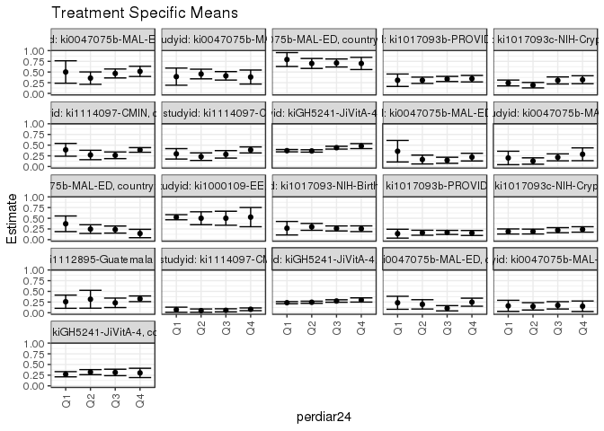

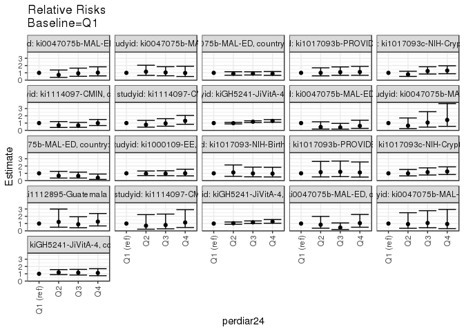

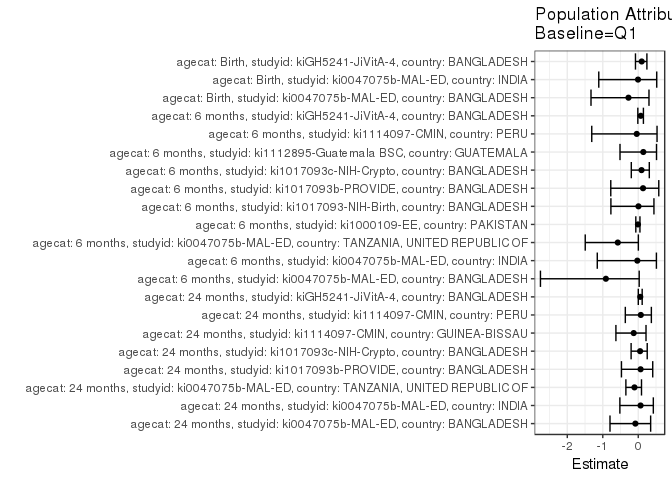

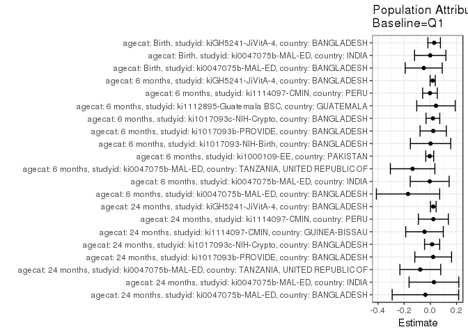

## Results Table

### Parameter: TSM

| agecat | studyid | country | intervention_level | baseline_level | estimate | ci_lower | ci_upper |
| --- | --- | --- | --- | --- | --- | --- | --- |
| Birth | ki0047075b-MAL-ED | BANGLADESH | Q1 | NA | 0.2333333 | 0.0816892 | 0.3849775 |
| Birth | ki0047075b-MAL-ED | BANGLADESH | Q2 | NA | 0.1960784 | 0.0869014 | 0.3052555 |
| Birth | ki0047075b-MAL-ED | BANGLADESH | Q3 | NA | 0.1052632 | 0.0434304 | 0.1670959 |
| Birth | ki0047075b-MAL-ED | BANGLADESH | Q4 | NA | 0.2469136 | 0.1528228 | 0.3410044 |
| Birth | ki0047075b-MAL-ED | INDIA | Q1 | NA | 0.1612903 | 0.0315025 | 0.2910781 |
| Birth | ki0047075b-MAL-ED | INDIA | Q2 | NA | 0.1492537 | 0.0637215 | 0.2347860 |
| Birth | ki0047075b-MAL-ED | INDIA | Q3 | NA | 0.1733333 | 0.0874556 | 0.2592110 |
| Birth | ki0047075b-MAL-ED | INDIA | Q4 | NA | 0.1515152 | 0.0288848 | 0.2741455 |
| Birth | kiGH5241-JiVitA-4 | BANGLADESH | Q1 | NA | 0.2714777 | 0.2106226 | 0.3323328 |
| Birth | kiGH5241-JiVitA-4 | BANGLADESH | Q2 | NA | 0.3212996 | 0.2620441 | 0.3805552 |
| Birth | kiGH5241-JiVitA-4 | BANGLADESH | Q3 | NA | 0.3138298 | 0.2384889 | 0.3891706 |
| Birth | kiGH5241-JiVitA-4 | BANGLADESH | Q4 | NA | 0.3030303 | 0.1943482 | 0.4117124 |
| 6 months | ki0047075b-MAL-ED | BANGLADESH | Q1 | NA | 0.3571429 | 0.1056271 | 0.6086586 |
| 6 months | ki0047075b-MAL-ED | BANGLADESH | Q2 | NA | 0.1632653 | 0.0595617 | 0.2669689 |
| 6 months | ki0047075b-MAL-ED | BANGLADESH | Q3 | NA | 0.1458333 | 0.0750852 | 0.2165815 |
| 6 months | ki0047075b-MAL-ED | BANGLADESH | Q4 | NA | 0.2195122 | 0.1297370 | 0.3092874 |
| 6 months | ki0047075b-MAL-ED | INDIA | Q1 | NA | 0.2000000 | 0.0428696 | 0.3571304 |
| 6 months | ki0047075b-MAL-ED | INDIA | Q2 | NA | 0.1282051 | 0.0538548 | 0.2025554 |
| 6 months | ki0047075b-MAL-ED | INDIA | Q3 | NA | 0.2142857 | 0.1328742 | 0.2956973 |
| 6 months | ki0047075b-MAL-ED | INDIA | Q4 | NA | 0.2857143 | 0.1357326 | 0.4356959 |
| 6 months | ki0047075b-MAL-ED | TANZANIA, UNITED REPUBLIC OF | Q1 | NA | 0.3703704 | 0.1878515 | 0.5528893 |
| 6 months | ki0047075b-MAL-ED | TANZANIA, UNITED REPUBLIC OF | Q2 | NA | 0.2463768 | 0.1444986 | 0.3482551 |
| 6 months | ki0047075b-MAL-ED | TANZANIA, UNITED REPUBLIC OF | Q3 | NA | 0.2352941 | 0.1528078 | 0.3177804 |
| 6 months | ki0047075b-MAL-ED | TANZANIA, UNITED REPUBLIC OF | Q4 | NA | 0.1428571 | 0.0446804 | 0.2410339 |
| 6 months | ki1000109-EE | PAKISTAN | Q1 | NA | 0.5236364 | 0.4645278 | 0.5827449 |
| 6 months | ki1000109-EE | PAKISTAN | Q2 | NA | 0.5000000 | 0.3485818 | 0.6514182 |
| 6 months | ki1000109-EE | PAKISTAN | Q3 | NA | 0.5000000 | 0.3364497 | 0.6635503 |
| 6 months | ki1000109-EE | PAKISTAN | Q4 | NA | 0.5263158 | 0.3015017 | 0.7511298 |
| 6 months | ki1017093-NIH-Birth | BANGLADESH | Q1 | NA | 0.2666667 | 0.1082768 | 0.4250565 |
| 6 months | ki1017093-NIH-Birth | BANGLADESH | Q2 | NA | 0.2983871 | 0.2177786 | 0.3789956 |

[output cut: 54 more lines]

### Parameter: E(Y)

| agecat | studyid | country | intervention_level | baseline_level | estimate | ci_lower | ci_upper |
| --- | --- | --- | --- | --- | --- | --- | --- |
| Birth | ki0047075b-MAL-ED | BANGLADESH | NA | NA | 0.1828794 | 0.1355257 | 0.2302330 |
| Birth | ki0047075b-MAL-ED | INDIA | NA | NA | 0.1601942 | 0.1099849 | 0.2104035 |
| Birth | kiGH5241-JiVitA-4 | BANGLADESH | NA | NA | 0.3004866 | 0.2649179 | 0.3360553 |
| 6 months | ki0047075b-MAL-ED | BANGLADESH | NA | NA | 0.1867220 | 0.1374205 | 0.2360234 |
| 6 months | ki0047075b-MAL-ED | INDIA | NA | NA | 0.1949153 | 0.1442678 | 0.2455627 |
| 6 months | ki0047075b-MAL-ED | TANZANIA, UNITED REPUBLIC OF | NA | NA | 0.2348178 | 0.1818480 | 0.2877876 |
| 6 months | ki1000109-EE | PAKISTAN | NA | NA | 0.5188172 | 0.4679751 | 0.5696593 |
| 6 months | ki1017093-NIH-Birth | BANGLADESH | NA | NA | 0.2681564 | 0.2306532 | 0.3056597 |
| 6 months | ki1017093b-PROVIDE | BANGLADESH | NA | NA | 0.1612350 | 0.1313580 | 0.1911120 |
| 6 months | ki1017093c-NIH-Crypto | BANGLADESH | NA | NA | 0.2097902 | 0.1799252 | 0.2396552 |
| 6 months | ki1112895-Guatemala BSC | GUATEMALA | NA | NA | 0.3010033 | 0.2489243 | 0.3530824 |
| 6 months | ki1114097-CMIN | PERU | NA | NA | 0.0675039 | 0.0480051 | 0.0870027 |
| 6 months | kiGH5241-JiVitA-4 | BANGLADESH | NA | NA | 0.2525357 | 0.2384780 | 0.2665934 |
| 24 months | ki0047075b-MAL-ED | BANGLADESH | NA | NA | 0.4622642 | 0.3949918 | 0.5295365 |
| 24 months | ki0047075b-MAL-ED | INDIA | NA | NA | 0.4185022 | 0.3541865 | 0.4828179 |
| 24 months | ki0047075b-MAL-ED | TANZANIA, UNITED REPUBLIC OF | NA | NA | 0.7149533 | 0.6543278 | 0.7755787 |
| 24 months | ki1017093b-PROVIDE | BANGLADESH | NA | NA | 0.3292894 | 0.2909105 | 0.3676684 |
| 24 months | ki1017093c-NIH-Crypto | BANGLADESH | NA | NA | 0.2568093 | 0.2190047 | 0.2946140 |
| 24 months | ki1114097-CMIN | GUINEA-BISSAU | NA | NA | 0.3457249 | 0.3054989 | 0.3859509 |
| 24 months | ki1114097-CMIN | PERU | NA | NA | 0.3192488 | 0.2749275 | 0.3635701 |
| 24 months | kiGH5241-JiVitA-4 | BANGLADESH | NA | NA | 0.3922559 | 0.3752678 | 0.4092440 |

### Parameter: RR

| agecat | studyid | country | intervention_level | baseline_level | estimate | ci_lower | ci_upper |
| --- | --- | --- | --- | --- | --- | --- | --- |
| Birth | ki0047075b-MAL-ED | BANGLADESH | Q1 | Q1 | 1.0000000 | 1.0000000 | 1.0000000 |
| Birth | ki0047075b-MAL-ED | BANGLADESH | Q2 | Q1 | 0.8403361 | 0.3570928 | 1.9775384 |
| Birth | ki0047075b-MAL-ED | BANGLADESH | Q3 | Q1 | 0.4511278 | 0.1878646 | 1.0833135 |
| Birth | ki0047075b-MAL-ED | BANGLADESH | Q4 | Q1 | 1.0582011 | 0.4981702 | 2.2478051 |
| Birth | ki0047075b-MAL-ED | INDIA | Q1 | Q1 | 1.0000000 | 1.0000000 | 1.0000000 |
| Birth | ki0047075b-MAL-ED | INDIA | Q2 | Q1 | 0.9253731 | 0.3445742 | 2.4851409 |
| Birth | ki0047075b-MAL-ED | INDIA | Q3 | Q1 | 1.0746667 | 0.4177096 | 2.7648597 |
| Birth | ki0047075b-MAL-ED | INDIA | Q4 | Q1 | 0.9393939 | 0.3000437 | 2.9411077 |
| Birth | kiGH5241-JiVitA-4 | BANGLADESH | Q1 | Q1 | 1.0000000 | 1.0000000 | 1.0000000 |
| Birth | kiGH5241-JiVitA-4 | BANGLADESH | Q2 | Q1 | 1.1835215 | 0.8888998 | 1.5757941 |
| Birth | kiGH5241-JiVitA-4 | BANGLADESH | Q3 | Q1 | 1.1560059 | 0.8309498 | 1.6082195 |
| Birth | kiGH5241-JiVitA-4 | BANGLADESH | Q4 | Q1 | 1.1162255 | 0.7330194 | 1.6997633 |
| 6 months | ki0047075b-MAL-ED | BANGLADESH | Q1 | Q1 | 1.0000000 | 1.0000000 | 1.0000000 |
| 6 months | ki0047075b-MAL-ED | BANGLADESH | Q2 | Q1 | 0.4571429 | 0.1770831 | 1.1801219 |
| 6 months | ki0047075b-MAL-ED | BANGLADESH | Q3 | Q1 | 0.4083333 | 0.1736283 | 0.9603052 |
| 6 months | ki0047075b-MAL-ED | BANGLADESH | Q4 | Q1 | 0.6146341 | 0.2722289 | 1.3877113 |
| 6 months | ki0047075b-MAL-ED | INDIA | Q1 | Q1 | 1.0000000 | 1.0000000 | 1.0000000 |
| 6 months | ki0047075b-MAL-ED | INDIA | Q2 | Q1 | 0.6410256 | 0.2414253 | 1.7020331 |
| 6 months | ki0047075b-MAL-ED | INDIA | Q3 | Q1 | 1.0714286 | 0.4476706 | 2.5642942 |
| 6 months | ki0047075b-MAL-ED | INDIA | Q4 | Q1 | 1.4285714 | 0.5553208 | 3.6750226 |
| 6 months | ki0047075b-MAL-ED | TANZANIA, UNITED REPUBLIC OF | Q1 | Q1 | 1.0000000 | 1.0000000 | 1.0000000 |
| 6 months | ki0047075b-MAL-ED | TANZANIA, UNITED REPUBLIC OF | Q2 | Q1 | 0.6652174 | 0.3496071 | 1.2657471 |
| 6 months | ki0047075b-MAL-ED | TANZANIA, UNITED REPUBLIC OF | Q3 | Q1 | 0.6352941 | 0.3469968 | 1.1631192 |
| 6 months | ki0047075b-MAL-ED | TANZANIA, UNITED REPUBLIC OF | Q4 | Q1 | 0.3857143 | 0.1655764 | 0.8985308 |
| 6 months | ki1000109-EE | PAKISTAN | Q1 | Q1 | 1.0000000 | 1.0000000 | 1.0000000 |
| 6 months | ki1000109-EE | PAKISTAN | Q2 | Q1 | 0.9548611 | 0.6911630 | 1.3191675 |
| 6 months | ki1000109-EE | PAKISTAN | Q3 | Q1 | 0.9548611 | 0.6755557 | 1.3496440 |
| 6 months | ki1000109-EE | PAKISTAN | Q4 | Q1 | 1.0051170 | 0.6461611 | 1.5634803 |
| 6 months | ki1017093-NIH-Birth | BANGLADESH | Q1 | Q1 | 1.0000000 | 1.0000000 | 1.0000000 |
| 6 months | ki1017093-NIH-Birth | BANGLADESH | Q2 | Q1 | 1.1189516 | 0.5826792 | 2.1487858 |

[output cut: 54 more lines]

### Parameter: PAR

| agecat | studyid | country | intervention_level | baseline_level | estimate | ci_lower | ci_upper |
| --- | --- | --- | --- | --- | --- | --- | --- |
| Birth | ki0047075b-MAL-ED | BANGLADESH | Q1 | NA | -0.0504540 | -0.1914136 | 0.0905057 |
| Birth | ki0047075b-MAL-ED | INDIA | Q1 | NA | -0.0010961 | -0.1206622 | 0.1184699 |
| Birth | kiGH5241-JiVitA-4 | BANGLADESH | Q1 | NA | 0.0290090 | -0.0188080 | 0.0768260 |
| 6 months | ki0047075b-MAL-ED | BANGLADESH | Q1 | NA | -0.1704209 | -0.4119598 | 0.0711181 |
| 6 months | ki0047075b-MAL-ED | INDIA | Q1 | NA | -0.0050847 | -0.1534903 | 0.1433208 |
| 6 months | ki0047075b-MAL-ED | TANZANIA, UNITED REPUBLIC OF | Q1 | NA | -0.1355526 | -0.3053640 | 0.0342588 |
| 6 months | ki1000109-EE | PAKISTAN | Q1 | NA | -0.0048192 | -0.0350374 | 0.0253991 |
| 6 months | ki1017093-NIH-Birth | BANGLADESH | Q1 | NA | 0.0014898 | -0.1524283 | 0.1554078 |
| 6 months | ki1017093b-PROVIDE | BANGLADESH | Q1 | NA | 0.0217001 | -0.0785608 | 0.1219610 |
| 6 months | ki1017093c-NIH-Crypto | BANGLADESH | Q1 | NA | 0.0193140 | -0.0332546 | 0.0718826 |
| 6 months | ki1112895-Guatemala BSC | GUATEMALA | Q1 | NA | 0.0429388 | -0.1039685 | 0.1898461 |
| 6 months | ki1114097-CMIN | PERU | Q1 | NA | -0.0029186 | -0.0589263 | 0.0530891 |
| 6 months | kiGH5241-JiVitA-4 | BANGLADESH | Q1 | NA | 0.0175787 | -0.0021637 | 0.0373211 |
| 24 months | ki0047075b-MAL-ED | BANGLADESH | Q1 | NA | -0.0377358 | -0.2913993 | 0.2159276 |
| 24 months | ki0047075b-MAL-ED | INDIA | Q1 | NA | 0.0271979 | -0.1625311 | 0.2169268 |
| 24 months | ki0047075b-MAL-ED | TANZANIA, UNITED REPUBLIC OF | Q1 | NA | -0.0767134 | -0.2324351 | 0.0790083 |
| 24 months | ki1017093b-PROVIDE | BANGLADESH | Q1 | NA | 0.0215971 | -0.1185816 | 0.1617759 |
| 24 months | ki1017093c-NIH-Crypto | BANGLADESH | Q1 | NA | 0.0133883 | -0.0443569 | 0.0711335 |
| 24 months | ki1114097-CMIN | GUINEA-BISSAU | Q1 | NA | -0.0445190 | -0.1878720 | 0.0988340 |
| 24 months | ki1114097-CMIN | PERU | Q1 | NA | 0.0229525 | -0.0913396 | 0.1372446 |
| 24 months | kiGH5241-JiVitA-4 | BANGLADESH | Q1 | NA | 0.0223848 | 0.0009690 | 0.0438007 |

### Parameter: PAF

| agecat | studyid | country | intervention_level | baseline_level | estimate | ci_lower | ci_upper |
| --- | --- | --- | --- | --- | --- | --- | --- |
| Birth | ki0047075b-MAL-ED | BANGLADESH | Q1 | NA | -0.2758865 | -1.3317992 | 0.3018754 |
| Birth | ki0047075b-MAL-ED | INDIA | Q1 | NA | -0.0068426 | -1.1130379 | 0.5202490 |
| Birth | kiGH5241-JiVitA-4 | BANGLADESH | Q1 | NA | 0.0965399 | -0.0785614 | 0.2432141 |
| 6 months | ki0047075b-MAL-ED | BANGLADESH | Q1 | NA | -0.9126984 | -2.7561488 | 0.0260196 |
| 6 months | ki0047075b-MAL-ED | INDIA | Q1 | NA | -0.0260870 | -1.1549453 | 0.5114240 |
| 6 months | ki0047075b-MAL-ED | TANZANIA, UNITED REPUBLIC OF | Q1 | NA | -0.5772669 | -1.4941471 | 0.0025565 |
| 6 months | ki1000109-EE | PAKISTAN | Q1 | NA | -0.0092887 | -0.0692555 | 0.0473149 |
| 6 months | ki1017093-NIH-Birth | BANGLADESH | Q1 | NA | 0.0055556 | -0.7711369 | 0.4416469 |
| 6 months | ki1017093b-PROVIDE | BANGLADESH | Q1 | NA | 0.1345868 | -0.7746487 | 0.5779785 |
| 6 months | ki1017093c-NIH-Crypto | BANGLADESH | Q1 | NA | 0.0920635 | -0.1962703 | 0.3109010 |
| 6 months | ki1112895-Guatemala BSC | GUATEMALA | Q1 | NA | 0.1426523 | -0.5146185 | 0.5146995 |
| 6 months | ki1114097-CMIN | PERU | Q1 | NA | -0.0432362 | -1.3107229 | 0.5290038 |
| 6 months | kiGH5241-JiVitA-4 | BANGLADESH | Q1 | NA | 0.0696087 | -0.0123355 | 0.1449199 |
| 24 months | ki0047075b-MAL-ED | BANGLADESH | Q1 | NA | -0.0816327 | -0.7966086 | 0.3488124 |
| 24 months | ki0047075b-MAL-ED | INDIA | Q1 | NA | 0.0649886 | -0.5184756 | 0.4242605 |
| 24 months | ki0047075b-MAL-ED | TANZANIA, UNITED REPUBLIC OF | Q1 | NA | -0.1072985 | -0.3490552 | 0.0911343 |
| 24 months | ki1017093b-PROVIDE | BANGLADESH | Q1 | NA | 0.0655870 | -0.4736437 | 0.4075043 |
| 24 months | ki1017093c-NIH-Crypto | BANGLADESH | Q1 | NA | 0.0521332 | -0.2015766 | 0.2522728 |
| 24 months | ki1114097-CMIN | GUINEA-BISSAU | Q1 | NA | -0.1287700 | -0.6298969 | 0.2182808 |
| 24 months | ki1114097-CMIN | PERU | Q1 | NA | 0.0718954 | -0.3649333 | 0.3689229 |
| 24 months | kiGH5241-JiVitA-4 | BANGLADESH | Q1 | NA | 0.0570670 | 0.0008836 | 0.1100910 |